# Homework #4

Lalitaambigai

10/17/2022

## Chick weights

The `ChickWeight` data set is part of the base package `datasets`. See `?ChickWeight` for details on the data. For all of the questions use `dplyr` functions whenever possible.

1. Download the RMarkdown file with these homework instructions to use as a template for your work. Make sure to replace “Your Name” in the YAML with your name. To get full points, show your R code (in a code chunk) and write answers to the questions.
2. (1 pt) What variables are part of the dataset?
- There are 4 variables in the data “ChickWeight”. The first variable is weight, this measures the weight of each chick and is a numerical input. The second variable is time, this numeric input tracks how many days old the chick is when the it was weighed. The third variable is a number identifier, identifying which chick is being weighted. Each chick was given a number, 1 - 50 to track their progress. The fourth variable is a factor variable given to each chick to track which diet the chick is receiving. Their are 4 different diets that the group of chicks were subjected to.

```r
head(ChickWeight)
```

```
##   weight Time Chick Diet
## 1     42    0     1    1
## 2     51    2     1    1
## 3     59    4     1    1
## 4     64    6     1    1
## 5     76    8     1    1
## 6     93   10     1    1
```

```r
dim(ChickWeight)
```

```
## [1] 578   4
```

```r
?ChickWeight
```

```
## starting httpd help server ... done
```

```r
#View(ChickWeight)
```

3. (2 pts) Get a frequency breakdown of the number of chicks, their average weight and the standard deviation of the weights in each of the diets at the start of the study.  
   0.5 pts of extra credit: construct a ggplot that shows average weights by diet with an interval (shown as a line) of +- the standard deviation around the averages. (Hint: read this article regarding [ggplot error bars](http://www.sthda.com/english/wiki/ggplot2-error-bars-quick-start-guide-r-software-and-data-visualization))
- The data was first filtered by time because at the start of the diet the time was eaual to 0 days. After this the remaining data was grouped by diet type. From their a count of the number of chicks was conducted, an average weight for those chicks was calculated, and the standard deviation of the chicks was also calculated. Below is a breakdown of the data. Diet 1 contains 20 chicks with an average weight of 41.4 grams, and a standard deviation of .9947 grams. Diet 2 contains 10 chicks with an average weight of 40.7 grams, and a standard deviation of 1.4944 grams. Diet 3 contains 10 chicks with an average weight of 40.8 grams and a standard deviation of 1.0328 grams. Finally, diet 4 contains 10 chicks with an averge weight of 41 grams, and a standard deviation of 1.0541 grams.

```r
diets_start <- filter(ChickWeight,Time==0) %>%
  group_by(Diet) %>%
  summarize(
    frequency = n(),
    average_weight = mean(weight,na.rm=TRUE),
    sd_weight = sd(weight,na.rm=TRUE)
  )
head(diets_start)
```

```
## # A tibble: 4 × 4
##   Diet  frequency average_weight sd_weight
##   <fct>     <int>          <dbl>     <dbl>
## 1 1            20           41.4     0.995
## 2 2            10           40.7     1.49
## 3 3            10           40.8     1.03
## 4 4            10           41       1.05
```

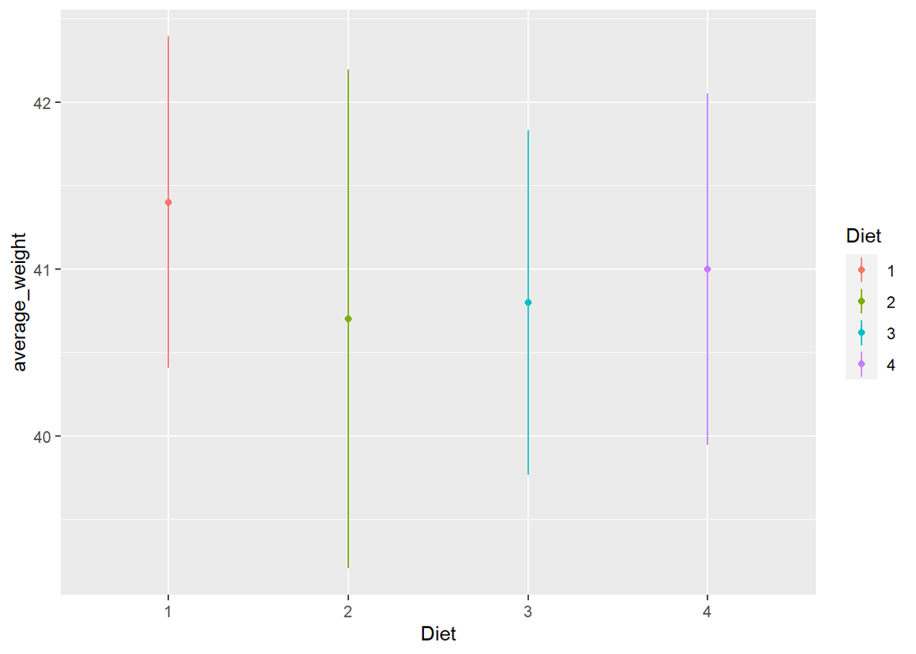

```r
ggplot(diets_start,aes(x=Diet,y=average_weight,color=Diet))+geom_linerange(aes(ymin=average_weight-sd_weight,ymax=average_weight+sd_weight))+geom_point()
```

4. (2.5 pts) Each chick should have twelve weight measurements. Use the dplyr package to identify how many chicks have a complete set of weight measurements and how many measurements there are on average in the incomplete cases. Extract a subset of the data for all chicks with complete information and name the data set `complete`. (Hint: you might want to use mutate to introduce a helper variable consisting of the number of observations) -45 chicks have a complete data set of 12 observations, while 5 chicks have incomplete data sets. The average number of observations for the incomplete observations per chick is 7.6 as seen below.

```r
chicken <- ChickWeight %>%
  group_by(Chick) %>% mutate(
    obs = n()
)

complete <- filter(chicken,obs==12)
incomplete <- filter(chicken,obs<12)

number_complete <- complete %>%
  group_by(Chick) %>%
  summarize(observation = n())

number_incomplete <- incomplete %>%
  group_by(Chick) %>%
  summarize(observations = n())

observations_incomplete <- sum(number_incomplete['observations'])
average <- observations_incomplete/5

n_c <- number_complete %>%
  summarize(complete_observations = n())

n_i <- number_incomplete %>%
  summarize(incomplete_observations = n())

answer <- n_c %>% mutate(
  n_i,
  total_incomplete = sum(number_incomplete['observations']),
  average_incomplete = observations_incomplete/5
)

head(answer)
```

```
## # A tibble: 1 × 4
##   complete_observations incomplete_observations total_incomplete
##                   <int>                   <int>            <int>
## 1                    45                       5               38
## # ℹ 1 more variable: average_incomplete <dbl>
```

5. (.5 pt) In the complete data set introduce a new variable that measures the current weight difference compared to day 0. Name this variable `weightgain`. (Hint: use mutate and `?mutate` to check the parameter `.by`. This parameter can create a temporary `group_by` so that we can do calculation in each subgroup, i.e. for each combination of chick and diet, `weight - min(weight)`)

```r
complete <- complete %>%
  mutate(
  weightgain = weight-weight[Time==0]
)
```

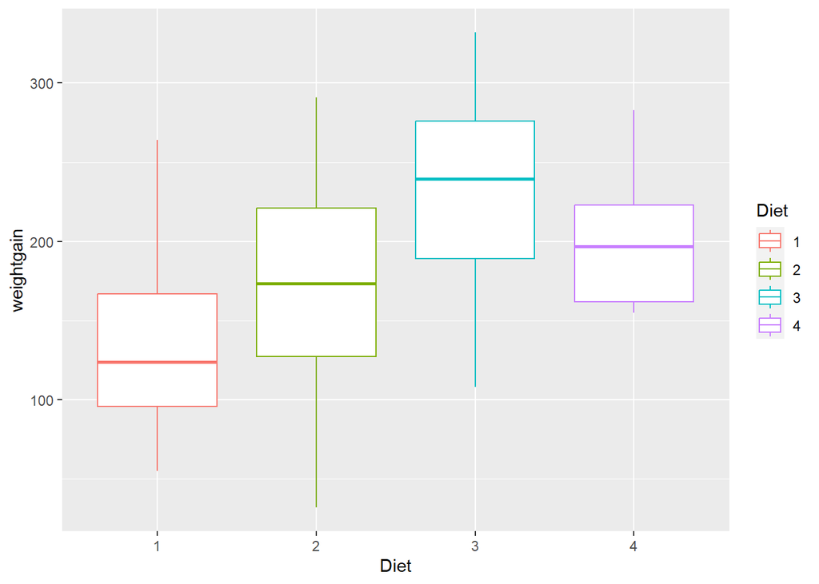

```r
day21 <- filter(complete,Time==21)
day21 <- day21 %>%
  group_by(Diet) %>% mutate(
  weightgain_median = median(weightgain)
)
ggplot(day21,aes(x=Diet,y=weightgain,color=Diet))+geom_boxplot()
```

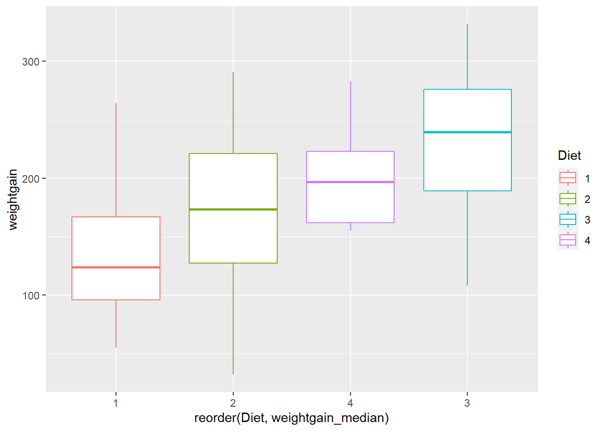

```r
ggplot(day21,aes(x=reorder(Diet,weightgain_median),y=weightgain,color=Diet))+geom_boxplot()
```